# Call Generator — Demo

## Setup

This is just to demonstrate/double-check a basic setup with three features, f1, f2, and f3, with probabilities 0.5, 0.3, and 0.15 respectively.

All $2^3 = 8$ world states and their probabilities under the default world.

```python
rows = []
for state in world.all_states():
    rows.append({
        "State": "".join("T" if v else "F" for v in state.values()),
        **{k: "T" if v else "F" for k, v in state.items()},
        "P(state)": f"{world.state_prob(state):.4f}",
    })

pd.DataFrame(rows).set_index("State")
```

| State | f1 | f2 | f3 | P(state) |
| --- | --- | --- | --- | --- |
| FFF | F | F | F | 0.2975 |
| FFT | F | F | T | 0.0525 |
| FTF | F | T | F | 0.1275 |
| FTT | F | T | T | 0.0225 |
| TFF | T | F | F | 0.2975 |
| TFT | T | F | T | 0.0525 |
| TTF | T | T | F | 0.1275 |
| TTT | T | T | T | 0.0225 |

## 2. Lexica

```python
rows = []
for lex in ALL_LEXICA:
    for state in world.all_states():
        ts = lex.true_signals(state)
        rows.append({
            "Lexicon": lex.name,
            "State": "".join("T" if v else "F" for v in state.values()),
            "True signals": ", ".join(ts) if ts else "—",
        })

df = pd.DataFrame(rows)
df.pivot(index="State", columns="Lexicon", values="True signals")
```

| Lexicon State | BaselineLexicon | CompositionLexicon | EntailmentLexicon | IdiomLexicon | OverlapLexicon |
| --- | --- | --- | --- | --- | --- |
| FFF | — | — | — | — | — |
| FFT | — | — | — | AB | B |
| FTF | B | B | A, B | B | A, B |
| FTT | B | B | A, B | B, AB | A, B |
| TFF | A | A, AB | A | A | A |
| TFT | A | A, AB | A | A, AB | A, B |
| TTF | A, B | A, B | A, B | A, B | A, B |
| TTT | A, B | A, B | A, B | A, B, AB | A, B |

## 3. Sequence distributions and weight schemes

Here are a few examples of the way in which different lexicon-productionRule combinations give rise to different distributions over sequences of signals.

### 3.1 Baseline lexicon

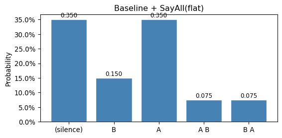

```python
lex = BaselineLexicon()
rule = SayAllRule(ordering="flat")
gen = Generator(world=world, lexicon=lex, rule=rule)

dist = gen.distribution()
labels = [(" ".join(u) if u else "(silence)") for u in dist.keys()]
probs  = list(dist.values())

fig, ax = plt.subplots(figsize=(6, 3))
bars = ax.bar(labels, probs, color="steelblue", edgecolor="white")
ax.set_ylabel("Probability")
ax.set_title("Baseline + SayAll(flat)")
ax.yaxis.set_major_formatter(mticker.PercentFormatter(xmax=1))
for b, p in zip(bars, probs):
    ax.text(b.get_x() + b.get_width()/2, p + 0.003, f"{p:.3f}",
            ha="center", va="bottom", fontsize=9)
plt.tight_layout()
plt.show()
```

Note that *silence* is when no signals are true, so the speaker has nothing to say (e.g., here that’s $1-pr(f1) \times 1-pr(f2)$).

Here’s how the distribution changes with other ordering schemes:

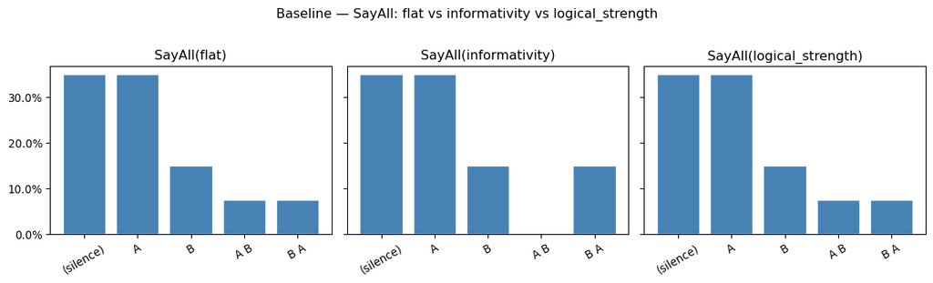

```python
schemes = ["flat", "informativity", "logical_strength"]
fig, axes = plt.subplots(1, 3, figsize=(12, 3.5), sharey=True)

all_utts_bl: set = set()
dists_bl = {}
for scheme in schemes:
    g = Generator(world=world, lexicon=lex, rule=SayAllRule(ordering=scheme))
    d = g.distribution()
    dists_bl[scheme] = d
    all_utts_bl |= d.keys()

all_utts_bl_sorted = [()] + sorted((u for u in all_utts_bl if u), key=lambda u: (len(u), u))
xlabels_bl = [(" ".join(u) if u else "(silence)") for u in all_utts_bl_sorted]

for ax, scheme in zip(axes, schemes):
    ps = [dists_bl[scheme].get(u, 0.0) for u in all_utts_bl_sorted]
    ax.bar(xlabels_bl, ps, color="steelblue", edgecolor="white")
    ax.set_title(f"SayAll({scheme})")
    ax.yaxis.set_major_formatter(mticker.PercentFormatter(xmax=1))
    ax.tick_params(axis="x", rotation=30)

fig.suptitle("Baseline — SayAll: flat vs informativity vs logical_strength", y=1.02)
plt.tight_layout()
plt.show()
```

### 3.2 Entailment lexicon

Just to showcase a different lexicon:

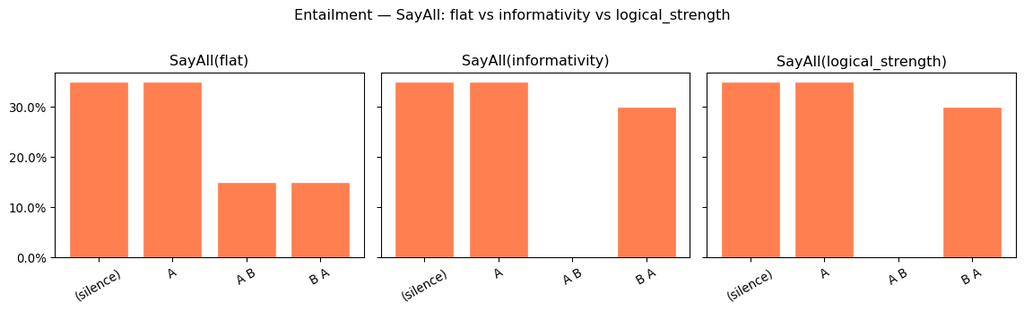

```python
from call_generator import EntailmentLexicon
lex_ent = EntailmentLexicon()

schemes = ["flat", "informativity", "logical_strength"]
fig, axes = plt.subplots(1, 3, figsize=(12, 3.5), sharey=True)

all_utts_ent: set = set()
dists_ent = {}
for scheme in schemes:
    g = Generator(world=world, lexicon=lex_ent, rule=SayAllRule(ordering=scheme))
    d = g.distribution()
    dists_ent[scheme] = d
    all_utts_ent |= d.keys()

all_utts_ent_sorted = [()] + sorted((u for u in all_utts_ent if u), key=lambda u: (len(u), u))
xlabels_ent = [(" ".join(u) if u else "(silence)") for u in all_utts_ent_sorted]

for ax, scheme in zip(axes, schemes):
    ps = [dists_ent[scheme].get(u, 0.0) for u in all_utts_ent_sorted]
    ax.bar(xlabels_ent, ps, color="coral", edgecolor="white")
    ax.set_title(f"SayAll({scheme})")
    ax.yaxis.set_major_formatter(mticker.PercentFormatter(xmax=1))
    ax.tick_params(axis="x", rotation=30)

fig.suptitle("Entailment — SayAll: flat vs informativity vs logical_strength", y=1.02)
plt.tight_layout()
plt.show()
```

This is with a deterministic choice. You could also sample proportionally to signal weights to make the difference less stark; but note that the two schemes actually agree here: under the Entailment lexicon, B is true in 4/8 worlds and A in 6/8 worlds, so both logical strength and informativity assign higher weight to B. With a deterministic sort, both put all weight on B A — the difference between schemes only emerges when their weight orderings disagree.

## 4. Different production: SayOne rule

Unlike SayAll, SayOne picks exactly one signal from the true set. Under the Baseline lexicon shows a difference between ordering schemes: *informativity* breaks the symmetry between A and B, while *logical strength* does not.

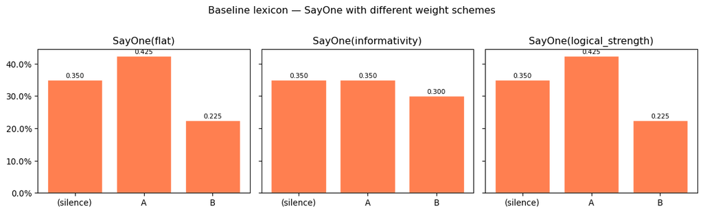

```python
schemes = ["flat", "informativity", "logical_strength"]
fig, axes = plt.subplots(1, 3, figsize=(12, 3.5), sharey=True)

for ax, scheme in zip(axes, schemes):
    g = Generator(world=world, lexicon=lex, rule=SayOneRule(selection=scheme))
    d = g.distribution()
    utts_sorted = [()] + sorted((u for u in d if u), key=lambda u: (len(u), u))
    labs = [(" ".join(u) if u else "(silence)") for u in utts_sorted]
    ps = [d.get(u, 0.0) for u in utts_sorted]
    ax.bar(labs, ps, color="coral", edgecolor="white")
    ax.set_title(f"SayOne({scheme})")
    ax.yaxis.set_major_formatter(mticker.PercentFormatter(xmax=1))
    for b, p in zip(ax.patches, ps):
        if p > 0.01:
            ax.text(b.get_x() + b.get_width()/2, p + 0.003, f"{p:.3f}",
                    ha="center", va="bottom", fontsize=8)

fig.suptitle("Baseline lexicon — SayOne with different weight schemes", y=1.02)
plt.tight_layout()
plt.show()
```

# Practicalities

The above is just to showcase how these things interact. In practical terms, I’m ultimately just sampling $n$ (here: 1000, following Chiara’s setup) feature-sequence pairs for a given production rule-lexicon combination. So the data looks like this (saved as a CSV).

Here’s how it looks like

```python
df = pd.read_csv("../data/calls.csv")
df.head()
```

|  | sample_id | lexicon | rule | f1 | f2 | f3 | true_signals | utterance |
| --- | --- | --- | --- | --- | --- | --- | --- | --- |
| 0 | 0 | BaselineLexicon | SayAll(flat) | 0 | 0 | 0 | NaN | NaN |
| 1 | 1 | BaselineLexicon | SayAll(flat) | 1 | 0 | 0 | A | A |
| 2 | 2 | BaselineLexicon | SayAll(flat) | 1 | 0 | 0 | A | A |
| 3 | 3 | BaselineLexicon | SayAll(flat) | 0 | 0 | 0 | NaN | NaN |
| 4 | 4 | BaselineLexicon | SayAll(flat) | 0 | 1 | 0 | B | B |

```python
df.tail()
```

|  | sample_id | lexicon | rule | f1 | f2 | f3 | true_signals | utterance |
| --- | --- | --- | --- | --- | --- | --- | --- | --- |
| 29995 | 995 | CompositionLexicon | SayOne(logical_strength) | 0 | 0 | 0 | NaN | NaN |
| 29996 | 996 | CompositionLexicon | SayOne(logical_strength) | 0 | 0 | 0 | NaN | NaN |
| 29997 | 997 | CompositionLexicon | SayOne(logical_strength) | 0 | 0 | 0 | NaN | NaN |
| 29998 | 998 | CompositionLexicon | SayOne(logical_strength) | 1 | 0 | 1 | A,AB | AB |
| 29999 | 999 | CompositionLexicon | SayOne(logical_strength) | 0 | 0 | 0 | NaN | NaN |